# The Hidden Crisis: Youth Out-of-School Rates Worldwide

Author

Published

April 14, 2026

## Introduction

Around the world, millions of young people of **upper secondary school age** are not in school. This report explores the **out-of-school rate** — the percentage of youth who should be enrolled in upper secondary education but are not — using data from UNICEF across multiple countries and years (2010–2020).

This is not merely an education issue. It is a crisis of *opportunity*, *inequality*, and *human potential*. The data reveals stark disparities between wealthy and poorer nations, and persistent gender gaps that leave girls behind in many regions.

Key questions this report addresses:

- Which countries have the **highest out-of-school rates**?
- Is the situation **improving over time** globally?
- Does a country’s **wealth** explain its out-of-school rate?

## Data & Methods

The analysis uses two datasets:

- **UNICEF Indicator Data**: Out-of-school rate for upper secondary youth (%), by country, year, and sex
- **World Bank Metadata**: Country-level GDP per capita, life expectancy, and other development indicators

```python
import polars as pl
import pandas as pd
import geopandas as gpd
from plotnine import *
import warnings
warnings.filterwarnings("ignore")

# --- Load data ---
indicator = pl.read_csv("unicef_indicator_2.csv")
metadata  = pl.read_csv("unicef_metadata.csv")

# --- Filter to Total sex only ---
indicator_total = indicator.filter(pl.col("sex") == "Total")

# --- Latest value per country (for map + bar) ---
latest = (
    indicator_total
    .sort("time_period", descending=True)
    .group_by("country", "alpha_3_code")
    .agg(pl.col("obs_value").first().alias("out_of_school_rate"))
).to_pandas(use_pyarrow_extension_array=False)

# --- Global average per year (for time series) ---
time_series = (
    indicator_total
    .group_by("time_period")
    .agg(pl.col("obs_value").mean().alias("avg_rate"))
    .sort("time_period")
).to_pandas(use_pyarrow_extension_array=False)

# --- Merge with metadata for scatterplot (2015) ---
meta_2015 = (
    metadata
    .filter(pl.col("year") == 2015)
    .select([
        "alpha_3_code",
        pl.col("GDP per capita (constant 2015 US$)").alias("gdp_per_capita"),
    ])
).to_pandas(use_pyarrow_extension_array=False)

indicator_2015 = (
    indicator_total
    .filter(pl.col("time_period") == 2015)
    .select(["alpha_3_code", "country", "obs_value"])
).to_pandas(use_pyarrow_extension_array=False)

scatter_data = (
    indicator_2015
    .merge(meta_2015, on="alpha_3_code", how="inner")
    .dropna()
)

# --- Summary stats ---
n_countries = indicator_total["country"].n_unique()
year_min    = indicator_total["time_period"].min()
year_max    = indicator_total["time_period"].max()

print(f"Countries in dataset : {n_countries}")
print(f"Years covered        : {year_min} – {year_max}")
print(f"Rows (Total sex only): {len(indicator_total)}")
```

```
Countries in dataset : 113
Years covered        : 2010 – 2020
Rows (Total sex only): 113
```

## Where Is the Crisis Worst?

```python
import geodatasets
world = gpd.read_file(geodatasets.get_path('naturalearth:admin_0_countries'))
world_merged = world.merge(
    latest, left_on="ISO_A3", right_on="alpha_3_code", how="left"
)

map_plot = (
    ggplot(world_merged)
    + geom_map(aes(fill="out_of_school_rate"), color="white", size=0.1)
    + scale_fill_gradient(
        low="#ffffcc", high="#d73027",
        na_value="lightgrey",
        name="Rate (%)"
    )
    + labs(
        title="Out-of-School Rate for Upper Secondary Youth",
        subtitle="Latest available year per country  |  Grey = no data",
        caption="Source: UNICEF"
    )
    + theme_void()
    + theme(
        plot_title=element_text(size=13, face="bold"),
        plot_subtitle=element_text(size=10),
        legend_position="right"
    )
)
map_plot.draw()
```

[output not shown]

## Which Countries Are Falling Most Behind?

The bar chart below ranks the **15 countries with the highest out-of-school rates**, based on the most recent data available for each.

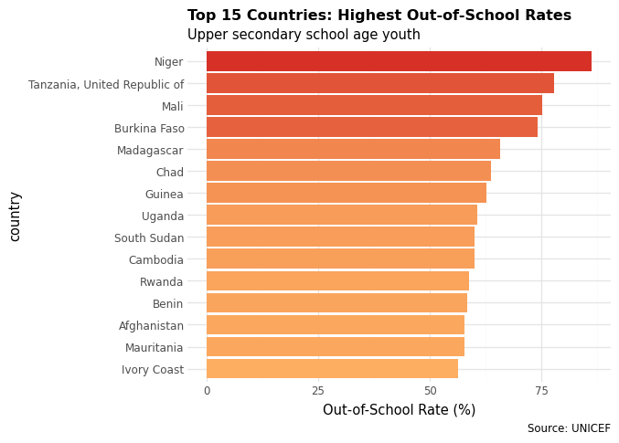

Figure 2: Top 15 countries by most-recent out-of-school rate for upper secondary youth

```python
top15 = (
    latest
    .dropna(subset=["out_of_school_rate"])
    .nlargest(15, "out_of_school_rate")
    .sort_values("out_of_school_rate")
)
top15["country"] = pd.Categorical(
    top15["country"], categories=top15["country"]
)

bar_plot = (
    ggplot(top15, aes(x="country", y="out_of_school_rate",
                      fill="out_of_school_rate"))
    + geom_col()
    + coord_flip()
    + scale_fill_gradient(low="#fdae61", high="#d73027", guide=None)
    + labs(
        title="Top 15 Countries: Highest Out-of-School Rates",
        subtitle="Upper secondary school age youth",
        x=None,
        y="Out-of-School Rate (%)",
        caption="Source: UNICEF"
    )
    + theme_minimal()
    + theme(
        plot_title=element_text(size=12, face="bold"),
        axis_text_y=element_text(size=9)
    )
)
bar_plot.draw()
```

Several countries have out-of-school rates **exceeding 60%**, meaning the majority of young people who should be in upper secondary school are not. This represents a generational loss of education and opportunity.

## Does Wealth Explain It?

The scatterplot below compares each country’s **GDP per capita** (2015, log scale) against its **out-of-school rate** (2015), with a linear regression line overlaid.

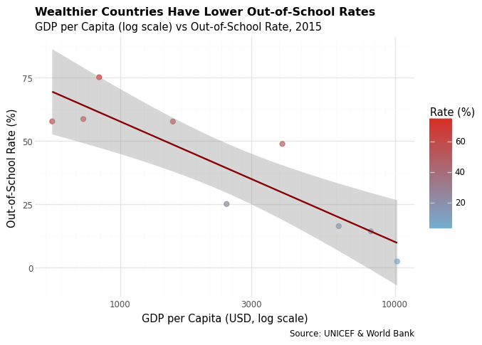

Figure 3: GDP per capita (log scale) vs out-of-school rate, 2015 — with linear regression line

```python
scatter_plot = (
    ggplot(scatter_data, aes(x="gdp_per_capita", y="obs_value"))
    + geom_point(aes(color="obs_value"), size=2.5, alpha=0.7)
    + geom_smooth(method="lm", color="darkred", se=True)
    + scale_color_gradient(low="#74add1", high="#d73027", name="Rate (%)")
    + scale_x_log10()
    + labs(
        title="Wealthier Countries Have Lower Out-of-School Rates",
        subtitle="GDP per Capita (log scale) vs Out-of-School Rate, 2015",
        x="GDP per Capita (USD, log scale)",
        y="Out-of-School Rate (%)",
        caption="Source: UNICEF & World Bank"
    )
    + theme_minimal()
    + theme(plot_title=element_text(size=12, face="bold"))
)
scatter_plot.draw()
```

The **negative correlation** is clear: as GDP per capita rises, out-of-school rates fall sharply. The regression line confirms this trend. However, there is significant variation — some middle-income countries still struggle, while strong policy investment can make a difference even at lower income levels.

## Is the Trend Improving Over Time?

The time-series chart tracks the **global average out-of-school rate** year by year from 2010 to 2020, averaged across all countries with available data.

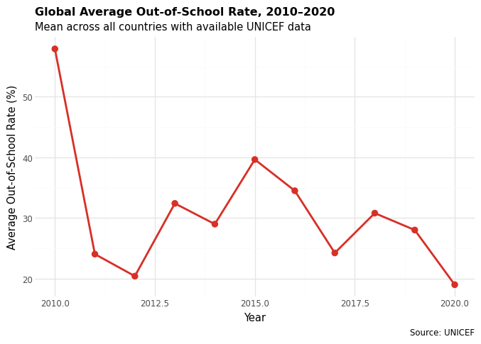

Figure 4: Global average out-of-school rate for upper secondary youth, 2010–2020

```python
ts_plot = (
    ggplot(time_series, aes(x="time_period", y="avg_rate"))
    + geom_line(color="#d73027", size=1.2)
    + geom_point(color="#d73027", size=3)
    + labs(
        title="Global Average Out-of-School Rate, 2010–2020",
        subtitle="Mean across all countries with available UNICEF data",
        x="Year",
        y="Average Out-of-School Rate (%)",
        caption="Source: UNICEF"
    )
    + theme_minimal()
    + theme(plot_title=element_text(size=12, face="bold"))
)
ts_plot.draw()
```

Even modest reductions in the global average represent millions of additional young people gaining access to education. Sustained progress requires continued investment in educational infrastructure, teacher training, and poverty reduction.

## Conclusion

The data tells a sobering story. Youth exclusion from upper secondary education is **not random** — it clusters in the world’s poorest regions and is deeply tied to national wealth. Yet the data also shows that progress *is* possible.

Key takeaways:

- **Geography matters**: Sub-Saharan Africa bears a disproportionate share of the global out-of-school burden.
- **Wealth is a strong predictor**: Richer nations consistently achieve lower out-of-school rates, but policy choices also play a role.
- **The trend is mixed**: The global average has changed over the decade, but progress is uneven across regions.

Investing in education is not just a moral imperative — it is an economic one. Keeping young people in school breaks cycles of poverty, reduces inequality, and builds the human capital nations need to thrive. The question is not whether we can afford to act, but whether we can afford *not* to.

*Report prepared for BAA1030 | Data sources: UNICEF & World Bank*